# Risk Factor Analysis

## Outcome Variable

**Outcome Variable:** stunted

## Predictor Variables

**Intervention Variable:** mbmi

**Adjustment Set:**

unadjusted

## Stratifying Variables

The analysis was stratified on these variable(s):

- agecat
- studyid

The following strata were considered:

- agecat: 12 months, studyid: ki0047075b-MAL-ED
- agecat: 12 months, studyid: ki1017093-NIH-Birth
- agecat: 12 months, studyid: ki1017093b-PROVIDE
- agecat: 12 months, studyid: ki1017093c-NIH-Crypto
- agecat: 12 months, studyid: ki1066203-TanzaniaChild2
- agecat: 12 months, studyid: ki1126311-ZVITAMBO
- agecat: 12 months, studyid: ki1148112-LCNI-5
- agecat: 18 months, studyid: ki0047075b-MAL-ED
- agecat: 18 months, studyid: ki1017093-NIH-Birth
- agecat: 18 months, studyid: ki1017093b-PROVIDE
- agecat: 18 months, studyid: ki1017093c-NIH-Crypto
- agecat: 18 months, studyid: ki1066203-TanzaniaChild2
- agecat: 18 months, studyid: ki1126311-ZVITAMBO
- agecat: 18 months, studyid: ki1148112-LCNI-5
- agecat: 24 months, studyid: ki0047075b-MAL-ED
- agecat: 24 months, studyid: ki1017093-NIH-Birth
- agecat: 24 months, studyid: ki1017093b-PROVIDE
- agecat: 24 months, studyid: ki1017093c-NIH-Crypto
- agecat: 24 months, studyid: ki1066203-TanzaniaChild2
- agecat: 24 months, studyid: ki1126311-ZVITAMBO
- agecat: 24 months, studyid: ki1148112-LCNI-5
- agecat: 3 months, studyid: ki0047075b-MAL-ED
- agecat: 3 months, studyid: ki1017093-NIH-Birth
- agecat: 3 months, studyid: ki1017093b-PROVIDE
- agecat: 3 months, studyid: ki1017093c-NIH-Crypto
- agecat: 3 months, studyid: ki1066203-TanzaniaChild2
- agecat: 3 months, studyid: ki1126311-ZVITAMBO
- agecat: 6 months, studyid: ki0047075b-MAL-ED
- agecat: 6 months, studyid: ki1017093-NIH-Birth
- agecat: 6 months, studyid: ki1017093b-PROVIDE
- agecat: 6 months, studyid: ki1017093c-NIH-Crypto
- agecat: 6 months, studyid: ki1066203-TanzaniaChild2
- agecat: 6 months, studyid: ki1126311-ZVITAMBO
- agecat: 6 months, studyid: ki1148112-LCNI-5
- agecat: 9 months, studyid: ki0047075b-MAL-ED
- agecat: 9 months, studyid: ki1017093-NIH-Birth
- agecat: 9 months, studyid: ki1017093b-PROVIDE
- agecat: 9 months, studyid: ki1017093c-NIH-Crypto
- agecat: 9 months, studyid: ki1066203-TanzaniaChild2
- agecat: 9 months, studyid: ki1126311-ZVITAMBO
- agecat: 9 months, studyid: ki1148112-LCNI-5
- agecat: Birth, studyid: ki0047075b-MAL-ED
- agecat: Birth, studyid: ki1017093-NIH-Birth
- agecat: Birth, studyid: ki1017093c-NIH-Crypto
- agecat: Birth, studyid: ki1126311-ZVITAMBO

### Dropped Strata

Some strata were dropped due to rare outcomes:

- agecat: 12 months, studyid: ki1066203-TanzaniaChild2
- agecat: 18 months, studyid: ki1066203-TanzaniaChild2
- agecat: 24 months, studyid: ki1066203-TanzaniaChild2
- agecat: 24 months, studyid: ki1126311-ZVITAMBO
- agecat: 3 months, studyid: ki1017093b-PROVIDE
- agecat: 3 months, studyid: ki1066203-TanzaniaChild2
- agecat: 6 months, studyid: ki1066203-TanzaniaChild2
- agecat: 9 months, studyid: ki1066203-TanzaniaChild2
- agecat: Birth, studyid: ki1017093-NIH-Birth
- agecat: Birth, studyid: ki1017093c-NIH-Crypto

## Methods Detail

We’re interested in the causal parameters $E[Y_a]$ for all values of $a \in \mathcal{A}$. These parameters represent the mean outcome if, possibly contrary to fact, we intervened to set all units to have $A=a$. Under the randomization and positivity assumptions, these are identified by the statistical parameters $\psi_a=E_W[E_{Y|A,W}(Y|A=a,W)]$. In addition, we’re interested in the mean of $Y$, $E[Y]$ under no intervention (the observed mean). We will estimate these parameters by using SuperLearner to fit the relevant likelihood factors – $E_{Y|A,W}(Y|A=a,W)$ and $p(A=a|W)$, and then updating our likelihood fit using a joint TMLE.

For unadjusted analyses ($W=\{\}$), initial likelihoods were estimated using Lrnr_glm to estimate the simple $E(Y|A)$ and Lrnr_mean to estimate $p(A)$. For adjusted analyses, a small library containing Lrnr_glmnet, Lrnr_xgboost, and Lrnr_mean was used.

Having estimated these parameters, we will then use the delta method to estimate relative risks and attributable risks relative to a prespecified baseline level of $A$.

# Results Detail

## Results Plots

[figure not shown]

[figure not shown]

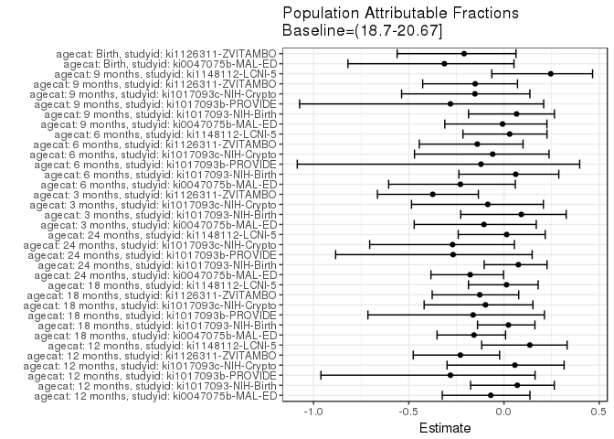

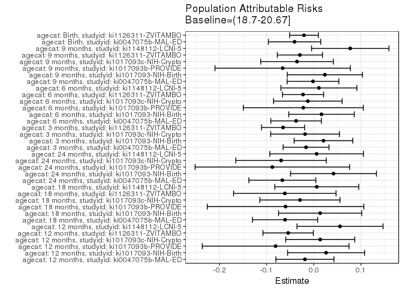

## Data Summary

| agecat | studyid | A | n | nA | nAY0 | nAY1 |
| --- | --- | --- | --- | --- | --- | --- |
| 12 months | ki0047075b-MAL-ED | (18.7-20.67] | 1609 | 208 | 148 | 60 |
| 12 months | ki0047075b-MAL-ED | (20.67-23.47] | 1609 | 440 | 303 | 137 |
| 12 months | ki0047075b-MAL-ED | <=18.7 | 1609 | 123 | 74 | 49 |
| 12 months | ki0047075b-MAL-ED | >23.47 | 1609 | 838 | 650 | 188 |
| 12 months | ki1017093-NIH-Birth | (18.7-20.67] | 491 | 132 | 86 | 46 |
| 12 months | ki1017093-NIH-Birth | (20.67-23.47] | 491 | 149 | 98 | 51 |
| 12 months | ki1017093-NIH-Birth | <=18.7 | 491 | 102 | 48 | 54 |
| 12 months | ki1017093-NIH-Birth | >23.47 | 491 | 108 | 75 | 33 |
| 12 months | ki1017093b-PROVIDE | (18.7-20.67] | 153 | 38 | 24 | 14 |
| 12 months | ki1017093b-PROVIDE | (20.67-23.47] | 153 | 48 | 37 | 11 |
| 12 months | ki1017093b-PROVIDE | <=18.7 | 153 | 22 | 9 | 13 |
| 12 months | ki1017093b-PROVIDE | >23.47 | 153 | 45 | 39 | 6 |
| 12 months | ki1017093c-NIH-Crypto | (18.7-20.67] | 706 | 127 | 98 | 29 |
| 12 months | ki1017093c-NIH-Crypto | (20.67-23.47] | 706 | 214 | 159 | 55 |
| 12 months | ki1017093c-NIH-Crypto | <=18.7 | 706 | 73 | 43 | 30 |
| 12 months | ki1017093c-NIH-Crypto | >23.47 | 706 | 292 | 235 | 57 |
| 12 months | ki1066203-TanzaniaChild2 | (18.7-20.67] | 349 | 32 | 30 | 2 |
| 12 months | ki1066203-TanzaniaChild2 | (20.67-23.47] | 349 | 91 | 75 | 16 |
| 12 months | ki1066203-TanzaniaChild2 | <=18.7 | 349 | 4 | 4 | 0 |
| 12 months | ki1066203-TanzaniaChild2 | >23.47 | 349 | 222 | 188 | 34 |
| 12 months | ki1126311-ZVITAMBO | (18.7-20.67] | 1451 | 278 | 197 | 81 |
| 12 months | ki1126311-ZVITAMBO | (20.67-23.47] | 1451 | 506 | 393 | 113 |
| 12 months | ki1126311-ZVITAMBO | <=18.7 | 1451 | 78 | 52 | 26 |
| 12 months | ki1126311-ZVITAMBO | >23.47 | 1451 | 589 | 465 | 124 |
| 12 months | ki1148112-LCNI-5 | (18.7-20.67] | 309 | 107 | 69 | 38 |
| 12 months | ki1148112-LCNI-5 | (20.67-23.47] | 309 | 102 | 55 | 47 |
| 12 months | ki1148112-LCNI-5 | <=18.7 | 309 | 67 | 33 | 34 |
| 12 months | ki1148112-LCNI-5 | >23.47 | 309 | 33 | 25 | 8 |
| 18 months | ki0047075b-MAL-ED | (18.7-20.67] | 1540 | 199 | 110 | 89 |
| 18 months | ki0047075b-MAL-ED | (20.67-23.47] | 1540 | 421 | 230 | 191 |

[output cut: 166 more lines]

## Results Table

### Parameter: TSM

| agecat | studyid | intervention_level | baseline_level | estimate | ci_lower | ci_upper |
| --- | --- | --- | --- | --- | --- | --- |
| 12 months | ki0047075b-MAL-ED | (18.7-20.67] | NA | 0.2884615 | 0.2268738 | 0.3500493 |
| 12 months | ki0047075b-MAL-ED | (20.67-23.47] | NA | 0.3113636 | 0.2680838 | 0.3546435 |
| 12 months | ki0047075b-MAL-ED | <=18.7 | NA | 0.3983740 | 0.3118295 | 0.4849185 |
| 12 months | ki0047075b-MAL-ED | >23.47 | NA | 0.2243437 | 0.1960914 | 0.2525959 |
| 12 months | ki1017093-NIH-Birth | (18.7-20.67] | NA | 0.3484848 | 0.2671160 | 0.4298537 |
| 12 months | ki1017093-NIH-Birth | (20.67-23.47] | NA | 0.3422819 | 0.2660196 | 0.4185441 |
| 12 months | ki1017093-NIH-Birth | <=18.7 | NA | 0.5294118 | 0.4324483 | 0.6263752 |
| 12 months | ki1017093-NIH-Birth | >23.47 | NA | 0.3055556 | 0.2185909 | 0.3925202 |
| 12 months | ki1017093b-PROVIDE | (18.7-20.67] | NA | 0.3684211 | 0.2145467 | 0.5222954 |
| 12 months | ki1017093b-PROVIDE | (20.67-23.47] | NA | 0.2291667 | 0.1098758 | 0.3484576 |
| 12 months | ki1017093b-PROVIDE | <=18.7 | NA | 0.5909091 | 0.3847840 | 0.7970342 |
| 12 months | ki1017093b-PROVIDE | >23.47 | NA | 0.1333333 | 0.0336870 | 0.2329796 |
| 12 months | ki1017093c-NIH-Crypto | (18.7-20.67] | NA | 0.2283465 | 0.1552894 | 0.3014035 |
| 12 months | ki1017093c-NIH-Crypto | (20.67-23.47] | NA | 0.2570093 | 0.1984205 | 0.3155982 |
| 12 months | ki1017093c-NIH-Crypto | <=18.7 | NA | 0.4109589 | 0.2980141 | 0.5239038 |
| 12 months | ki1017093c-NIH-Crypto | >23.47 | NA | 0.1952055 | 0.1497116 | 0.2406994 |
| 12 months | ki1126311-ZVITAMBO | (18.7-20.67] | NA | 0.2913669 | 0.2379343 | 0.3447995 |
| 12 months | ki1126311-ZVITAMBO | (20.67-23.47] | NA | 0.2233202 | 0.1870201 | 0.2596202 |
| 12 months | ki1126311-ZVITAMBO | <=18.7 | NA | 0.3333333 | 0.2286821 | 0.4379845 |
| 12 months | ki1126311-ZVITAMBO | >23.47 | NA | 0.2105263 | 0.1775910 | 0.2434617 |
| 12 months | ki1148112-LCNI-5 | (18.7-20.67] | NA | 0.3551402 | 0.2643179 | 0.4459625 |
| 12 months | ki1148112-LCNI-5 | (20.67-23.47] | NA | 0.4607843 | 0.3638936 | 0.5576750 |
| 12 months | ki1148112-LCNI-5 | <=18.7 | NA | 0.5074627 | 0.3875580 | 0.6273674 |
| 12 months | ki1148112-LCNI-5 | >23.47 | NA | 0.2424242 | 0.0959720 | 0.3888765 |
| 18 months | ki0047075b-MAL-ED | (18.7-20.67] | NA | 0.4472362 | 0.3781325 | 0.5163398 |
| 18 months | ki0047075b-MAL-ED | (20.67-23.47] | NA | 0.4536817 | 0.4061102 | 0.5012532 |
| 18 months | ki0047075b-MAL-ED | <=18.7 | NA | 0.5500000 | 0.4609598 | 0.6390402 |
| 18 months | ki0047075b-MAL-ED | >23.47 | NA | 0.3112500 | 0.2791556 | 0.3433444 |
| 18 months | ki1017093-NIH-Birth | (18.7-20.67] | NA | 0.5737705 | 0.4859232 | 0.6616178 |
| 18 months | ki1017093-NIH-Birth | (20.67-23.47] | NA | 0.5460993 | 0.4638326 | 0.6283660 |

[output cut: 110 more lines]

### Parameter: E(Y)

| agecat | studyid | intervention_level | baseline_level | estimate | ci_lower | ci_upper |
| --- | --- | --- | --- | --- | --- | --- |
| 12 months | ki0047075b-MAL-ED | NA | NA | 0.2697328 | 0.2671201 | 0.2723454 |
| 12 months | ki1017093-NIH-Birth | NA | NA | 0.3747454 | 0.3675917 | 0.3818991 |
| 12 months | ki1017093b-PROVIDE | NA | NA | 0.2875817 | 0.2635134 | 0.3116500 |
| 12 months | ki1017093c-NIH-Crypto | NA | NA | 0.2422096 | 0.2375649 | 0.2468543 |
| 12 months | ki1126311-ZVITAMBO | NA | NA | 0.2370779 | 0.2351418 | 0.2390140 |
| 12 months | ki1148112-LCNI-5 | NA | NA | 0.4110032 | 0.4016921 | 0.4203143 |
| 18 months | ki0047075b-MAL-ED | NA | NA | 0.3863636 | 0.3822635 | 0.3904638 |
| 18 months | ki1017093-NIH-Birth | NA | NA | 0.5874730 | 0.5787181 | 0.5962279 |
| 18 months | ki1017093b-PROVIDE | NA | NA | 0.3687943 | 0.3456883 | 0.3919003 |
| 18 months | ki1017093c-NIH-Crypto | NA | NA | 0.3012618 | 0.2959445 | 0.3065791 |
| 18 months | ki1126311-ZVITAMBO | NA | NA | 0.4818942 | 0.4767402 | 0.4870481 |
| 18 months | ki1148112-LCNI-5 | NA | NA | 0.4901408 | 0.4818606 | 0.4984211 |
| 24 months | ki0047075b-MAL-ED | NA | NA | 0.3749157 | 0.3706049 | 0.3792265 |
| 24 months | ki1017093-NIH-Birth | NA | NA | 0.5547786 | 0.5457419 | 0.5638153 |
| 24 months | ki1017093b-PROVIDE | NA | NA | 0.3288591 | 0.3011724 | 0.3565457 |
| 24 months | ki1017093c-NIH-Crypto | NA | NA | 0.2568093 | 0.2507080 | 0.2629107 |
| 24 months | ki1148112-LCNI-5 | NA | NA | 0.4391892 | 0.4277656 | 0.4506128 |
| 3 months | ki0047075b-MAL-ED | NA | NA | 0.1540648 | 0.1532318 | 0.1548978 |
| 3 months | ki1017093-NIH-Birth | NA | NA | 0.2280702 | 0.2238869 | 0.2322534 |
| 3 months | ki1017093c-NIH-Crypto | NA | NA | 0.2142857 | 0.2114495 | 0.2171220 |
| 3 months | ki1126311-ZVITAMBO | NA | NA | 0.1737773 | 0.1714147 | 0.1761399 |
| 6 months | ki0047075b-MAL-ED | NA | NA | 0.1635071 | 0.1619864 | 0.1650278 |
| 6 months | ki1017093-NIH-Birth | NA | NA | 0.2681564 | 0.2625210 | 0.2737919 |
| 6 months | ki1017093b-PROVIDE | NA | NA | 0.1830065 | 0.1761132 | 0.1898999 |
| 6 months | ki1017093c-NIH-Crypto | NA | NA | 0.2097902 | 0.2049372 | 0.2146432 |
| 6 months | ki1126311-ZVITAMBO | NA | NA | 0.1615646 | 0.1604972 | 0.1626320 |
| 6 months | ki1148112-LCNI-5 | NA | NA | 0.3686747 | 0.3616877 | 0.3756617 |
| 9 months | ki0047075b-MAL-ED | NA | NA | 0.2069810 | 0.2051187 | 0.2088433 |
| 9 months | ki1017093-NIH-Birth | NA | NA | 0.3570020 | 0.3521549 | 0.3618490 |
| 9 months | ki1017093b-PROVIDE | NA | NA | 0.2341772 | 0.2154630 | 0.2528914 |
| 9 months | ki1017093c-NIH-Crypto | NA | NA | 0.2322946 | 0.2282534 | 0.2363359 |
| 9 months | ki1126311-ZVITAMBO | NA | NA | 0.1940120 | 0.1917767 | 0.1962473 |
| 9 months | ki1148112-LCNI-5 | NA | NA | 0.3156250 | 0.3062570 | 0.3249930 |
| Birth | ki0047075b-MAL-ED | NA | NA | 0.1298246 | 0.1284032 | 0.1312459 |
| Birth | ki1126311-ZVITAMBO | NA | NA | 0.0986152 | 0.0979018 | 0.0993285 |

### Parameter: RR

| agecat | studyid | intervention_level | baseline_level | estimate | ci_lower | ci_upper |
| --- | --- | --- | --- | --- | --- | --- |
| 12 months | ki0047075b-MAL-ED | (20.67-23.47] | (18.7-20.67] | 1.0793939 | 0.8366365 | 1.3925896 |
| 12 months | ki0047075b-MAL-ED | <=18.7 | (18.7-20.67] | 1.3810298 | 1.0184000 | 1.8727842 |
| 12 months | ki0047075b-MAL-ED | >23.47 | (18.7-20.67] | 0.7777247 | 0.6069797 | 0.9965008 |
| 12 months | ki1017093-NIH-Birth | (20.67-23.47] | (18.7-20.67] | 0.9822002 | 0.7112720 | 1.3563267 |
| 12 months | ki1017093-NIH-Birth | <=18.7 | (18.7-20.67] | 1.5191816 | 1.1290942 | 2.0440391 |
| 12 months | ki1017093-NIH-Birth | >23.47 | (18.7-20.67] | 0.8768116 | 0.6067749 | 1.2670243 |
| 12 months | ki1017093b-PROVIDE | (20.67-23.47] | (18.7-20.67] | 0.6220238 | 0.3191282 | 1.2124079 |
| 12 months | ki1017093b-PROVIDE | <=18.7 | (18.7-20.67] | 1.6038961 | 0.9307796 | 2.7637937 |
| 12 months | ki1017093b-PROVIDE | >23.47 | (18.7-20.67] | 0.3619048 | 0.1537374 | 0.8519399 |
| 12 months | ki1017093c-NIH-Crypto | (20.67-23.47] | (18.7-20.67] | 1.1255237 | 0.7598769 | 1.6671168 |
| 12 months | ki1017093c-NIH-Crypto | <=18.7 | (18.7-20.67] | 1.7997166 | 1.1804008 | 2.7439660 |
| 12 months | ki1017093c-NIH-Crypto | >23.47 | (18.7-20.67] | 0.8548654 | 0.5754314 | 1.2699947 |
| 12 months | ki1126311-ZVITAMBO | (20.67-23.47] | (18.7-20.67] | 0.7664568 | 0.5998762 | 0.9792956 |
| 12 months | ki1126311-ZVITAMBO | <=18.7 | (18.7-20.67] | 1.1440329 | 0.7953049 | 1.6456725 |
| 12 months | ki1126311-ZVITAMBO | >23.47 | (18.7-20.67] | 0.7225471 | 0.5677796 | 0.9195017 |
| 12 months | ki1148112-LCNI-5 | (20.67-23.47] | (18.7-20.67] | 1.2974716 | 0.9317733 | 1.8066976 |
| 12 months | ki1148112-LCNI-5 | <=18.7 | (18.7-20.67] | 1.4289081 | 1.0087667 | 2.0240342 |
| 12 months | ki1148112-LCNI-5 | >23.47 | (18.7-20.67] | 0.6826156 | 0.3542193 | 1.3154680 |
| 18 months | ki0047075b-MAL-ED | (20.67-23.47] | (18.7-20.67] | 1.0144119 | 0.8416227 | 1.2226756 |
| 18 months | ki0047075b-MAL-ED | <=18.7 | (18.7-20.67] | 1.2297753 | 0.9831823 | 1.5382165 |
| 18 months | ki0047075b-MAL-ED | >23.47 | (18.7-20.67] | 0.6959410 | 0.5779601 | 0.8380057 |
| 18 months | ki1017093-NIH-Birth | (20.67-23.47] | (18.7-20.67] | 0.9517730 | 0.7678053 | 1.1798199 |
| 18 months | ki1017093-NIH-Birth | <=18.7 | (18.7-20.67] | 1.3392481 | 1.1088083 | 1.6175794 |
| 18 months | ki1017093-NIH-Birth | >23.47 | (18.7-20.67] | 0.8631293 | 0.6744961 | 1.1045165 |
| 18 months | ki1017093b-PROVIDE | (20.67-23.47] | (18.7-20.67] | 0.7954545 | 0.4528431 | 1.3972786 |
| 18 months | ki1017093b-PROVIDE | <=18.7 | (18.7-20.67] | 1.5166667 | 0.9184830 | 2.5044315 |
| 18 months | ki1017093b-PROVIDE | >23.47 | (18.7-20.67] | 0.5000000 | 0.2491569 | 1.0033838 |
| 18 months | ki1017093c-NIH-Crypto | (20.67-23.47] | (18.7-20.67] | 0.8575346 | 0.6081679 | 1.2091491 |
| 18 months | ki1017093c-NIH-Crypto | <=18.7 | (18.7-20.67] | 1.4669775 | 1.0257770 | 2.0979442 |
| 18 months | ki1017093c-NIH-Crypto | >23.47 | (18.7-20.67] | 0.7707907 | 0.5541861 | 1.0720556 |

[output cut: 75 more lines]

### Parameter: PAR

| agecat | studyid | intervention_level | baseline_level | estimate | ci_lower | ci_upper |
| --- | --- | --- | --- | --- | --- | --- |
| 12 months | ki0047075b-MAL-ED | (18.7-20.67] | NA | -0.0187288 | -0.0803720 | 0.0429144 |
| 12 months | ki1017093-NIH-Birth | (18.7-20.67] | NA | 0.0262606 | -0.0554221 | 0.1079433 |
| 12 months | ki1017093b-PROVIDE | (18.7-20.67] | NA | -0.0808394 | -0.2365847 | 0.0749060 |
| 12 months | ki1017093c-NIH-Crypto | (18.7-20.67] | NA | 0.0138632 | -0.0593414 | 0.0870678 |
| 12 months | ki1126311-ZVITAMBO | (18.7-20.67] | NA | -0.0542890 | -0.1077567 | -0.0008214 |
| 12 months | ki1148112-LCNI-5 | (18.7-20.67] | NA | 0.0558630 | -0.0354353 | 0.1471614 |
| 18 months | ki0047075b-MAL-ED | (18.7-20.67] | NA | -0.0608725 | -0.1300977 | 0.0083526 |
| 18 months | ki1017093-NIH-Birth | (18.7-20.67] | NA | 0.0137025 | -0.0745800 | 0.1019850 |
| 18 months | ki1017093b-PROVIDE | (18.7-20.67] | NA | -0.0597771 | -0.2259243 | 0.1063701 |
| 18 months | ki1017093c-NIH-Crypto | (18.7-20.67] | NA | -0.0292466 | -0.1143532 | 0.0558599 |
| 18 months | ki1126311-ZVITAMBO | (18.7-20.67] | NA | -0.0613157 | -0.1700688 | 0.0474374 |
| 18 months | ki1148112-LCNI-5 | (18.7-20.67] | NA | 0.0065343 | -0.0826518 | 0.0957204 |
| 24 months | ki0047075b-MAL-ED | (18.7-20.67] | NA | -0.0665737 | -0.1377098 | 0.0045625 |
| 24 months | ki1017093-NIH-Birth | (18.7-20.67] | NA | 0.0419580 | -0.0491665 | 0.1330826 |
| 24 months | ki1017093b-PROVIDE | (18.7-20.67] | NA | -0.0878076 | -0.2517514 | 0.0761362 |
| 24 months | ki1017093c-NIH-Crypto | (18.7-20.67] | NA | -0.0692776 | -0.1653554 | 0.0268002 |
| 24 months | ki1148112-LCNI-5 | (18.7-20.67] | NA | 0.0061995 | -0.0932303 | 0.1056293 |
| 3 months | ki0047075b-MAL-ED | (18.7-20.67] | NA | -0.0162409 | -0.0649478 | 0.0324661 |
| 3 months | ki1017093-NIH-Birth | (18.7-20.67] | NA | 0.0207531 | -0.0414852 | 0.0829914 |
| 3 months | ki1017093c-NIH-Crypto | (18.7-20.67] | NA | -0.0182724 | -0.0912800 | 0.0547352 |
| 3 months | ki1126311-ZVITAMBO | (18.7-20.67] | NA | -0.0650287 | -0.1107574 | -0.0192999 |
| 6 months | ki0047075b-MAL-ED | (18.7-20.67] | NA | -0.0374275 | -0.0911507 | 0.0162958 |
| 6 months | ki1017093-NIH-Birth | (18.7-20.67] | NA | 0.0165008 | -0.0530097 | 0.0860113 |
| 6 months | ki1017093b-PROVIDE | (18.7-20.67] | NA | -0.0221217 | -0.1494539 | 0.1052105 |
| 6 months | ki1017093c-NIH-Crypto | (18.7-20.67] | NA | -0.0124320 | -0.0852360 | 0.0603720 |
| 6 months | ki1126311-ZVITAMBO | (18.7-20.67] | NA | -0.0226459 | -0.0662483 | 0.0209565 |
| 6 months | ki1148112-LCNI-5 | (18.7-20.67] | NA | 0.0110105 | -0.0696510 | 0.0916719 |
| 9 months | ki0047075b-MAL-ED | (18.7-20.67] | NA | -0.0015498 | -0.0564144 | 0.0533148 |
| 9 months | ki1017093-NIH-Birth | (18.7-20.67] | NA | 0.0236686 | -0.0560771 | 0.1034144 |
| 9 months | ki1017093b-PROVIDE | (18.7-20.67] | NA | -0.0658228 | -0.2095111 | 0.0778655 |
| 9 months | ki1017093c-NIH-Crypto | (18.7-20.67] | NA | -0.0354219 | -0.1125882 | 0.0417444 |
| 9 months | ki1126311-ZVITAMBO | (18.7-20.67] | NA | -0.0293557 | -0.0772764 | 0.0185649 |
| 9 months | ki1148112-LCNI-5 | (18.7-20.67] | NA | 0.0775298 | -0.0046004 | 0.1596599 |
| Birth | ki0047075b-MAL-ED | (18.7-20.67] | NA | -0.0406300 | -0.0962218 | 0.0149618 |
| Birth | ki1126311-ZVITAMBO | (18.7-20.67] | NA | -0.0206509 | -0.0510875 | 0.0097857 |

### Parameter: PAF

| agecat | studyid | intervention_level | baseline_level | estimate | ci_lower | ci_upper |
| --- | --- | --- | --- | --- | --- | --- |
| 12 months | ki0047075b-MAL-ED | (18.7-20.67] | NA | -0.0694346 | -0.3242603 | 0.1363553 |
| 12 months | ki1017093-NIH-Birth | (18.7-20.67] | NA | 0.0700758 | -0.1754135 | 0.2642937 |
| 12 months | ki1017093b-PROVIDE | (18.7-20.67] | NA | -0.2811005 | -0.9614445 | 0.1632603 |
| 12 months | ki1017093c-NIH-Crypto | (18.7-20.67] | NA | 0.0572363 | -0.2989734 | 0.3157647 |
| 12 months | ki1126311-ZVITAMBO | (18.7-20.67] | NA | -0.2289924 | -0.4766298 | -0.0228849 |
| 12 months | ki1148112-LCNI-5 | (18.7-20.67] | NA | 0.1359188 | -0.1170034 | 0.3315720 |
| 18 months | ki0047075b-MAL-ED | (18.7-20.67] | NA | -0.1575525 | -0.3514586 | 0.0085322 |
| 18 months | ki1017093-NIH-Birth | (18.7-20.67] | NA | 0.0233245 | -0.1390882 | 0.1625802 |
| 18 months | ki1017093b-PROVIDE | (18.7-20.67] | NA | -0.1620879 | -0.7146461 | 0.2124040 |
| 18 months | ki1017093c-NIH-Crypto | (18.7-20.67] | NA | -0.0970805 | -0.4194319 | 0.1520653 |
| 18 months | ki1126311-ZVITAMBO | (18.7-20.67] | NA | -0.1272390 | -0.3771783 | 0.0773397 |
| 18 months | ki1148112-LCNI-5 | (18.7-20.67] | NA | 0.0133314 | -0.1864629 | 0.1794814 |
| 24 months | ki0047075b-MAL-ED | (18.7-20.67] | NA | -0.1775696 | -0.3836082 | -0.0022131 |
| 24 months | ki1017093-NIH-Birth | (18.7-20.67] | NA | 0.0756303 | -0.1039807 | 0.2260196 |
| 24 months | ki1017093b-PROVIDE | (18.7-20.67] | NA | -0.2670068 | -0.8842015 | 0.1480178 |
| 24 months | ki1017093c-NIH-Crypto | (18.7-20.67] | NA | -0.2697628 | -0.7054557 | 0.0546235 |
| 24 months | ki1148112-LCNI-5 | (18.7-20.67] | NA | 0.0141158 | -0.2403291 | 0.2163631 |
| 3 months | ki0047075b-MAL-ED | (18.7-20.67] | NA | -0.1054158 | -0.4714203 | 0.1695478 |
| 3 months | ki1017093-NIH-Birth | (18.7-20.67] | NA | 0.0909944 | -0.2271405 | 0.3266531 |
| 3 months | ki1017093c-NIH-Crypto | (18.7-20.67] | NA | -0.0852713 | -0.4855795 | 0.2071687 |
| 3 months | ki1126311-ZVITAMBO | (18.7-20.67] | NA | -0.3742068 | -0.6646132 | -0.1344643 |
| 6 months | ki0047075b-MAL-ED | (18.7-20.67] | NA | -0.2289042 | -0.6056755 | 0.0594578 |
| 6 months | ki1017093-NIH-Birth | (18.7-20.67] | NA | 0.0615342 | -0.2368844 | 0.2879544 |
| 6 months | ki1017093b-PROVIDE | (18.7-20.67] | NA | -0.1208791 | -1.0856718 | 0.3976186 |
| 6 months | ki1017093c-NIH-Crypto | (18.7-20.67] | NA | -0.0592593 | -0.4700210 | 0.2367250 |
| 6 months | ki1126311-ZVITAMBO | (18.7-20.67] | NA | -0.1401662 | -0.4446894 | 0.1001671 |
| 6 months | ki1148112-LCNI-5 | (18.7-20.67] | NA | 0.0298650 | -0.2154969 | 0.2256978 |
| 9 months | ki0047075b-MAL-ED | (18.7-20.67] | NA | -0.0074876 | -0.3107018 | 0.2255819 |
| 9 months | ki1017093-NIH-Birth | (18.7-20.67] | NA | 0.0662983 | -0.1859951 | 0.2649221 |
| 9 months | ki1017093b-PROVIDE | (18.7-20.67] | NA | -0.2810811 | -1.0735518 | 0.2085229 |
| 9 months | ki1017093c-NIH-Crypto | (18.7-20.67] | NA | -0.1524870 | -0.5377045 | 0.1362278 |
| 9 months | ki1126311-ZVITAMBO | (18.7-20.67] | NA | -0.1513088 | -0.4269115 | 0.0710623 |
| 9 months | ki1148112-LCNI-5 | (18.7-20.67] | NA | 0.2456388 | -0.0640625 | 0.4651999 |
| Birth | ki0047075b-MAL-ED | (18.7-20.67] | NA | -0.3129607 | -0.8193881 | 0.0525025 |
| Birth | ki1126311-ZVITAMBO | (18.7-20.67] | NA | -0.2094085 | -0.5610568 | 0.0630264 |